# Co-Culture Assay

Sachida Pokhrel

2025-04-18

## Things to know before Analysis

*This is applied for all the dataset for Co-culture Assay*

- One .csv file is loaded for one bacteria interacting with multiple yeast isolates
- There are three R chunks for each bacterial data.
- There are 16 different yeast interacting with one bacteria. So, to make it more clear in the plot and to make it less cumbersome, these yeast isolates are further categorised into 4 Yeast classes.
- There are 8 colonies of yeast and 8 colonies of bacteria at different distances in one plate. Data is taken only for bacterial colony size which reflects the impact of yeast on bacteria.
- Plots have multiple line graphs, thus the significant letters are not assigned through code and will be added later after exporting the plot.

```r
#load necessary library
library(ggplot2)
library(tidyverse)
library(ggpubr)
library(rstatix)
library(gvlma)
library(agricolae)
library(emmeans)
library(multcompView)
library(dplyr)
library(stringr)
library(tidyverse)
library(car)
library(nlme)
```

## *Curtobacterium flaccumfaciens* EMM_B44

Plot is generated using loop around the 4 different classes of yeast, coming up with 4 plots as an output which will be combined in one plot.

```r
#read data
B44 <- read.csv("CoCultureAssay/CoCultureAssayData/2024-08-09_PeaceAssay_B44.csv", na.strings = "na")


#load cbb color palette
cbbPalette <- c("#000000", "#E69F00", "#56B4E9", "#009E73", "#F0E442", "#0072B2", "#D55E00", "#CC79A7")
str(B44)
```

```
## 'data.frame':    1536 obs. of  8 variables:
##  $ Bacteria         : chr  "B44" "B44" "B44" "B44" ...
##  $ Yeast            : chr  "EMM_F3" "EMM_F3" "EMM_F3" "EMM_F3" ...
##  $ Class            : chr  "Dothideomycetes" "Dothideomycetes" "Dothideomycetes" "Dothideomycetes" ...
##  $ Replication      : int  1 1 1 1 1 1 1 1 2 2 ...
##  $ DAI              : int  2 2 2 2 2 2 2 2 2 2 ...
##  $ distance_to_yeast: num  0 11.4 17.4 24.9 31.8 ...
##  $ colony_diameter  : num  7.21 6.62 7.08 7.4 7.59 7.73 7.56 7.65 6.89 6.98 ...
##  $ increase         : num  0 0 0 0 0 0 0 0 0 0 ...
```

```r
#round off of the distance to yeast so that it is visibly a categorical variable
B44$distance_to_yeast <- round(B44$distance_to_yeast, 0)
#change into categorical dataset
B44$Replication=as.factor(B44$Replication)
B44$Yeast=as.factor(B44$Yeast)
B44$DAI=as.factor(B44$DAI)
B44$distance_to_yeast=as.factor(B44$distance_to_yeast)

#remove the data for the distance between yeast and bacteria at zero to remove misleading details
B44.no.contact <- B44[B44$distance_to_yeast != 0, ]
head(B44.no.contact)
```

```
##   Bacteria  Yeast           Class Replication DAI distance_to_yeast
## 2      B44 EMM_F3 Dothideomycetes           1   2                11
## 3      B44 EMM_F3 Dothideomycetes           1   2                17
## 4      B44 EMM_F3 Dothideomycetes           1   2                25
## 5      B44 EMM_F3 Dothideomycetes           1   2                32
## 6      B44 EMM_F3 Dothideomycetes           1   2                41
## 7      B44 EMM_F3 Dothideomycetes           1   2                48
##   colony_diameter increase
## 2            6.62        0
## 3            7.08        0
## 4            7.40        0
## 5            7.59        0
## 6            7.73        0
## 7            7.56        0
```

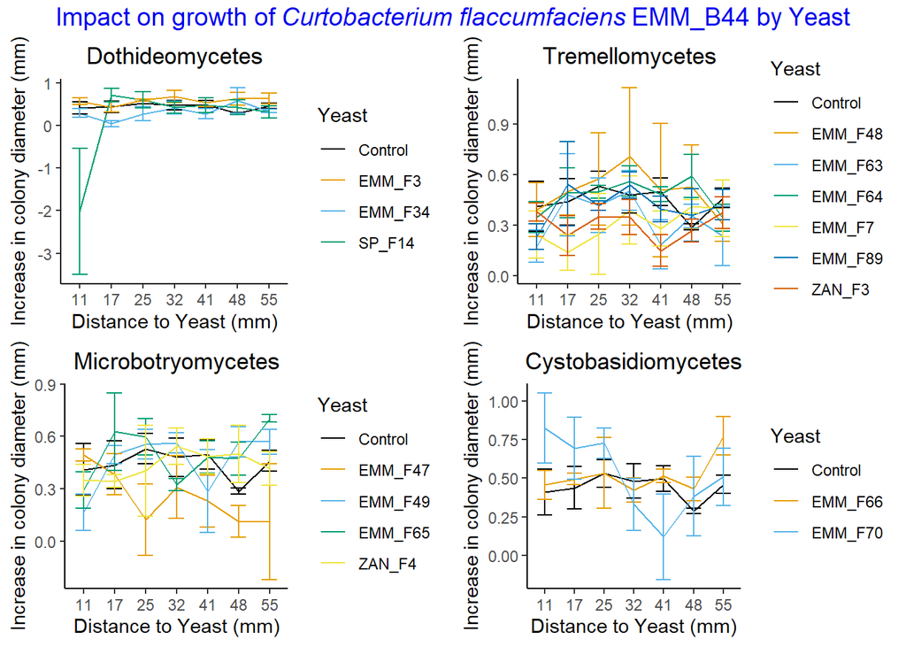

```r
#remove first data since it is a reference for increase in colony size and donot follow the assumption of linear model i.e. normal distributuion
B44.no.1st.data <-B44.no.contact[B44.no.contact$DAI != "2",]

# For plots purpose, I am only taking Day 6 since it has visible difference compared to other
B44.Day6 <- B44.no.contact[B44.no.contact$DAI == "6",]

#making a list object to store all the plots
plot_listB44 <- list()

# Get unique classes from the data
unique_class <- unique(B44.Day6$Class[B44.Day6$Class != "Control"])

# Loop through each class
for (i in seq_along(unique_class)) {

  # Filter for Control and the current class for using it in one iteration
  data <- B44.Day6 %>%
    filter(Class %in% c("Control", unique_class[i]))

  # Generate the plot
  p <- ggplot(data, aes(x = distance_to_yeast, y = increase, group = Yeast, color = Yeast)) +
    stat_summary(fun = mean, geom = "line") +   #making a line graph
    stat_summary(fun.data = mean_se, geom = "errorbar", width = 0.5) +   #standard error in plot
    ylab("Increase in colony diameter (mm)") +
    xlab("Distance to Yeast (mm)") +
    theme_classic() +
    scale_color_manual(values = cbbPalette) + #providing color blind palette
    ggtitle(unique_class[i]) +
    theme(plot.title = element_text(hjust = 0.5))

  # Store the plot in the list
  plot_listB44[[i]] <- p
}

#combining each iteration into one plot for one bacteria or dataset
combined_plotB44 <- ggarrange(plotlist = plot_listB44, ncol = 2, nrow = 2, common.legend = FALSE) #using the list generated from the loop, use it to make a combined plot without common legend.
# Annotation for the title
final_plotB44 <- annotate_figure(combined_plotB44,
                                 top = text_grob(
    expression("Impact on growth of"~italic("Curtobacterium flaccumfaciens")~"EMM_B44 by Yeast"), color = "Blue2", face = "bold", size = 14, hjust = 0.5))

#display final plot
print(final_plotB44)
```

### Stats for *Curtobacterium flaccumfaciens* EMM_B44

We are using linear mixed model. Our dependent variable or y is increase (increase in colony diameter from 1st data) and independent variables are different Yeast isolates, days after inoculation (DAI), and distance to yeast which is the distance between the yeast and bacterial colony in the plate. Each plate is replicated 3 times.

*This applies for all the dataset for Co-Culture Plate Assay*

```r
#filter data to remove 1st day data since the first data is taken as a base to measure the increase in colony size to rule out the variability that is caused by the drop inoculation. So, initially the increase in the colony diameter for 1st data for all colony is "0" that violates the assumption of normality, thus we remove that from analysis. This would be similar for all the bacterial isolates.

B44.no.1st.data <- B44.no.contact[B44.no.contact$DAI != "2",]
#We check interaction for all before cutting it down to the significant one.
B44try=lme(increase~DAI*distance_to_yeast*Yeast, data = B44.no.1st.data, random = ~1|Replication, na.action = na.omit)
anova(B44try)
```

```
##                             numDF denDF  F-value p-value
## (Intercept)                     1   670 90.89249  <.0001
## DAI                             2   670 30.61220  <.0001
## distance_to_yeast               6   670  8.56900  <.0001
## Yeast                          15   670  6.44533  <.0001
## DAI:distance_to_yeast          12   670  0.39830  0.9644
## DAI:Yeast                      30   670  0.54957  0.9768
## distance_to_yeast:Yeast        90   670  4.61931  <.0001
## DAI:distance_to_yeast:Yeast   180   670  0.42207  1.0000
```

```r
#removed interaction terms that were not significant.
resultsB44=lme(increase~DAI+distance_to_yeast*Yeast, data = B44.no.1st.data, random = ~1|Replication, na.action = na.omit)
anova(B44try, resultsB44) #check if complex model was better or not
```

```
##            Model  df       AIC      BIC    logLik   Test  L.Ratio p-value
## B44try         1 338 1304.5791 2829.046 -314.2896
## resultsB44     2 116  697.3477 1253.650 -232.6738 1 vs 2 163.2314  0.9989
```

```r
summary(resultsB44) #gives summary of the linear model
```

```
## Linear mixed-effects model fit by REML
##   Data: B44.no.1st.data
##        AIC     BIC    logLik
##   697.3477 1253.65 -232.6739
##
## Random effects:
##  Formula: ~1 | Replication
##         (Intercept)  Residual
## StdDev:  0.07293941 0.2709505
##
## Fixed effects:  increase ~ DAI + distance_to_yeast * Yeast
##                                       Value  Std.Error  DF    t-value p-value
## (Intercept)                       0.3254861 0.10038017 892   3.242534  0.0012
## DAI6                              0.0807143 0.02090428 892   3.861136  0.0001
## DAI8                              0.1761607 0.02090428 892   8.427015  0.0000
## distance_to_yeast17               0.1077778 0.12772729 892   0.843812  0.3990
## distance_to_yeast25               0.1622222 0.12772729 892   1.270067  0.2044
## distance_to_yeast32               0.0977778 0.12772729 892   0.765520  0.4442
## distance_to_yeast41               0.0822222 0.12772729 892   0.643733  0.5199
## distance_to_yeast48              -0.0866667 0.12772729 892  -0.678529  0.4976
## distance_to_yeast55               0.0522222 0.12772729 892   0.408857  0.6827
## YeastEMM_F3                       0.1388889 0.12772729 892   1.087386  0.2772
## YeastEMM_F34                     -0.0400000 0.12772729 892  -0.313167  0.7542
## YeastEMM_F47                      0.1044444 0.12772729 892   0.817714  0.4137
## YeastEMM_F48                      0.0166667 0.12772729 892   0.130486  0.8962
## YeastEMM_F49                     -0.1788889 0.12772729 892  -1.400553  0.1617
## YeastEMM_F63                     -0.2100000 0.12772729 892  -1.644128  0.1005
## YeastEMM_F64                     -0.0466667 0.12772729 892  -0.365362  0.7149
## YeastEMM_F65                     -0.1200000 0.12772729 892  -0.939502  0.3477
## YeastEMM_F66                     -0.0133333 0.12772729 892  -0.104389  0.9169
## YeastEMM_F7                      -0.0988889 0.12772729 892  -0.774219  0.4390
## YeastEMM_F70                      0.2588889 0.12772729 892   2.026888  0.0430
## YeastEMM_F89                     -0.1311111 0.12772729 892  -1.026493  0.3049
## YeastSP_F14                      -1.7966667 0.12772729 892 -14.066428  0.0000
## YeastZAN_F3                      -0.0444444 0.12772729 892  -0.347964  0.7279
## YeastZAN_F4                      -0.0588889 0.12772729 892  -0.461052  0.6449
## distance_to_yeast17:YeastEMM_F3  -0.2688889 0.18063366 892  -1.488587  0.1369
## distance_to_yeast25:YeastEMM_F3  -0.2288889 0.18063366 892  -1.267144  0.2054
## distance_to_yeast32:YeastEMM_F3  -0.0488889 0.18063366 892  -0.270652  0.7867
## distance_to_yeast41:YeastEMM_F3  -0.2055556 0.18063366 892  -1.137969  0.2554
```

[output cut: 3955 more lines]

```
## distance_to_yeast48:YeastZAN_F3
## distance_to_yeast55:YeastZAN_F3
## distance_to_yeast17:YeastZAN_F4
## distance_to_yeast25:YeastZAN_F4
## distance_to_yeast32:YeastZAN_F4
## distance_to_yeast41:YeastZAN_F4
## distance_to_yeast48:YeastZAN_F4   0.500
## distance_to_yeast55:YeastZAN_F4   0.500         0.500
##
## Standardized Within-Group Residuals:
##        Min         Q1        Med         Q3        Max
## -9.5098052 -0.4955909 -0.0177572  0.4758110  8.6693639
##
## Number of Observations: 1008
## Number of Groups: 3
```

```r
anova(resultsB44) #for overall x variables
```

```
##                         numDF denDF  F-value p-value
## (Intercept)                 1   892 90.89249  <.0001
## DAI                         2   892 35.59007  <.0001
## distance_to_yeast           6   892  9.96241  <.0001
## Yeast                      15   892  7.49340  <.0001
## distance_to_yeast:Yeast    90   892  5.37046  <.0001
```

### Loop for running analysis for each day separately for EMM_B44

Days after inoculation (DAI) as a factor is always significantly impacting the growth. Also, our plot will represent data for Day 6 thus we want relevant stats and comparison on Day 6 to present in the plot. So, loop was made for each Day data and removing DAI from the model and keeping rest of it present.

```r
# Extract all the unique days to be used for iteration in for loop
day <- unique(B44.no.1st.data$DAI)
# Initialize empty lists to store results
B44_Day <- list()
meansB44_Day <- list()
resultsB44_Day <- list()
model_summary_B44 <- list()
anova_table_B44 <- list()
Results_lsmeansB44 <- list()
filtered_comparisonsB44 <- list()

for (i in seq_along(day)) { #there are DAI 4, 6 and 8 that was extracted as unique days; sequence assigned will be 1 , 2 and 3 for each unique DAI

   # Filter data for the current day
  B44_Day[[i]] <- filter(B44.no.1st.data, DAI == day[i])
    # Fit the mixed effects model
  resultsB44_Day[[i]] <- lme(increase ~ distance_to_yeast * Yeast,
                            data = B44_Day[[i]],
                            random = ~1 | Replication,
                            na.action = na.omit) #Using mixed effect model here subsetting the data for the particular day

    model_summary_B44[[i]] <- summary(resultsB44_Day[[i]]) #store in the list value
  anova_table_B44[[i]] <- anova(resultsB44_Day[[i]]) #store in list value
   # Estimated marginal means
  meansB44_Day[[i]] <- emmeans(resultsB44_Day[[i]], ~ Yeast | distance_to_yeast)
    # Compact letter display with Tukey adjustment
  Results_lsmeansB44[[i]] <- multcomp::cld(meansB44_Day[[i]], alpha = 0.05,
                                          Letters = letters, reversed = TRUE,
                                          details = TRUE)
   # Print lsmeans results
  #print(Results_lsmeansB44[[i]])

  # Filter comparisons involving "Control"
  filtered_comparisonsB44[[i]] <- Results_lsmeansB44[[i]]$comparisons %>%
    filter(grepl("Control", contrast))
   # Print filtered contrasts
  print(filtered_comparisonsB44[[i]])
}
```

```
## distance_to_yeast = 11:
##  contrast          estimate    SE  df t.ratio p.value
##  Control - SP_F14   0.85667 0.188 222   4.568  0.0009
##  Control - EMM_F63  0.18667 0.188 222   0.995  0.9998
##  Control - EMM_F49  0.14667 0.188 222   0.782  1.0000
##  Control - EMM_F64  0.12333 0.188 222   0.658  1.0000
##  Control - EMM_F65  0.08000 0.188 222   0.427  1.0000
##  Control - EMM_F89  0.07667 0.188 222   0.409  1.0000
##  Control - ZAN_F3   0.06667 0.188 222   0.356  1.0000
##  Control - EMM_F66  0.03333 0.188 222   0.178  1.0000
##  Control - EMM_F7   0.01667 0.188 222   0.089  1.0000
##  EMM_F34 - Control  0.04667 0.188 222   0.249  1.0000
##  ZAN_F4 - Control   0.09000 0.188 222   0.480  1.0000
##  EMM_F48 - Control  0.11000 0.188 222   0.587  1.0000
##  EMM_F47 - Control  0.19000 0.188 222   1.013  0.9997
##  EMM_F70 - Control  0.20667 0.188 222   1.102  0.9993
##  EMM_F3 - Control   0.25000 0.188 222   1.333  0.9942
##
## distance_to_yeast = 17:
##  contrast          estimate    SE  df t.ratio p.value
##  Control - EMM_F34  0.36333 0.188 222   1.937  0.8555
##  Control - EMM_F7   0.21333 0.188 222   1.138  0.9990
##  Control - ZAN_F3   0.19333 0.188 222   1.031  0.9997
##  Control - EMM_F3   0.19000 0.188 222   1.013  0.9997
##  Control - EMM_F64  0.16000 0.188 222   0.853  1.0000
##  Control - EMM_F47  0.15000 0.188 222   0.800  1.0000
##  Control - SP_F14   0.13000 0.188 222   0.693  1.0000
##  Control - EMM_F66  0.12667 0.188 222   0.675  1.0000
##  Control - ZAN_F4   0.11333 0.188 222   0.604  1.0000
##  Control - EMM_F49  0.02333 0.188 222   0.124  1.0000
##  Control - EMM_F63  0.02333 0.188 222   0.124  1.0000
##  EMM_F65 - Control  0.01333 0.188 222   0.071  1.0000
##  EMM_F89 - Control  0.02000 0.188 222   0.107  1.0000
##  EMM_F48 - Control  0.08333 0.188 222   0.444  1.0000
##  EMM_F70 - Control  0.19667 0.188 222   1.049  0.9996
##
## distance_to_yeast = 25:
##  contrast          estimate    SE  df t.ratio p.value
##  Control - EMM_F34  0.37333 0.188 222   1.991  0.8278
##  Control - EMM_F47  0.34000 0.188 222   1.813  0.9093
```

[output cut: 329 more lines]

```
##  Control - EMM_F7   0.21333 0.233 222   0.914  0.9999
##  Control - SP_F14   0.14667 0.233 222   0.628  1.0000
##  Control - EMM_F34  0.14333 0.233 222   0.614  1.0000
##  Control - ZAN_F4   0.09667 0.233 222   0.414  1.0000
##  Control - EMM_F70  0.09000 0.233 222   0.386  1.0000
##  Control - EMM_F49  0.08667 0.233 222   0.371  1.0000
##  Control - EMM_F63  0.02667 0.233 222   0.114  1.0000
##  Control - EMM_F64  0.02000 0.233 222   0.086  1.0000
##  Control - EMM_F48  0.02000 0.233 222   0.086  1.0000
##  Control - EMM_F3   0.01333 0.233 222   0.057  1.0000
##  EMM_F66 - Control  0.29000 0.233 222   1.243  0.9973
##  EMM_F65 - Control  0.29000 0.233 222   1.243  0.9973
##
## Degrees-of-freedom method: containment
## P value adjustment: tukey method for comparing a family of 16 estimates
```

## *Curtobacterium flaccumfaciens* EMM_B30

```r
#read data
B30 <- read.csv("CoCultureAssay/CoCultureAssayData/2024-07-21_PeaceAssay_B30.csv", na.strings = "na")


#load cbb color palette
cbbPalette <- c("#000000", "#E69F00", "#56B4E9", "#009E73", "#F0E442", "#0072B2", "#D55E00", "#CC79A7")
str(B30)
```

```
## 'data.frame':    1536 obs. of  9 variables:
##  $ Bacteria               : chr  "B30" "B30" "B30" "B30" ...
##  $ Yeast                  : chr  "EMM_F3" "EMM_F3" "EMM_F3" "EMM_F3" ...
##  $ Class                  : chr  "Dothideomycetes" "Dothideomycetes" "Dothideomycetes" "Dothideomycetes" ...
##  $ Replication            : int  1 1 1 1 1 1 1 1 2 2 ...
##  $ DAI                    : int  2 2 2 2 2 2 2 2 2 2 ...
##  $ distance_to_yeast      : num  0 11.4 17.4 24.9 31.8 ...
##  $ colony_diameter        : num  7.42 7.42 8.06 8.06 8.22 7.99 8.11 6.61 7.05 7.83 ...
##  $ colony_diameter_control: num  8.01 8 7.69 7.41 6.92 7.72 6.82 7.08 7.71 7.54 ...
##  $ increase               : num  0 0 0 0 0 0 0 0 0 0 ...
```

```r
#round off of the distance to yeast so that it is visibly a categorical variable
B30$distance_to_yeast <- round(B30$distance_to_yeast, 0)
#change into categorical dataset
B30$Replication=as.factor(B30$Replication)
B30$Yeast=as.factor(B30$Yeast)
B30$DAI=as.factor(B30$DAI)
B30$distance_to_yeast=as.factor(B30$distance_to_yeast)

#remove the data for the distance zero
B30.no.contact <- B30[B30$distance_to_yeast != 0, ]
head(B30.no.contact)
```

```
##   Bacteria  Yeast           Class Replication DAI distance_to_yeast
## 2      B30 EMM_F3 Dothideomycetes           1   2                11
## 3      B30 EMM_F3 Dothideomycetes           1   2                17
## 4      B30 EMM_F3 Dothideomycetes           1   2                25
## 5      B30 EMM_F3 Dothideomycetes           1   2                32
## 6      B30 EMM_F3 Dothideomycetes           1   2                41
## 7      B30 EMM_F3 Dothideomycetes           1   2                48
##   colony_diameter colony_diameter_control increase
## 2            7.42                    8.00        0
## 3            8.06                    7.69        0
## 4            8.06                    7.41        0
## 5            8.22                    6.92        0
## 6            7.99                    7.72        0
## 7            8.11                    6.82        0
```

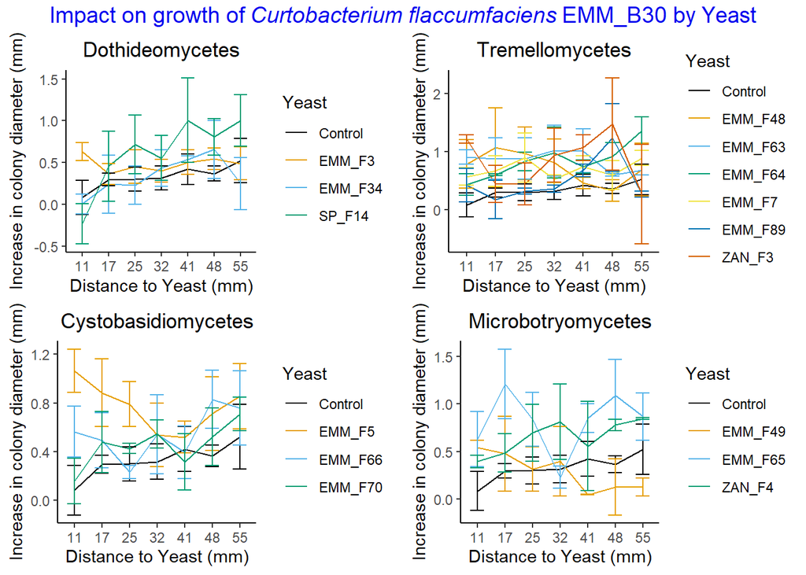

```r
# remove data first data since it is a reference for increase in colony size and donot follow the assumption of linear model i.e. normal distribution
B30.no.1st.data <-B30.no.contact[B30.no.contact$DAI != "2",]


B30.Day6 <- B30.no.contact[B30.no.contact$DAI == "6",]


plot_listB30 <- list()

# Get unique classes
unique_class <- unique(B30.Day6$Class[B30.Day6$Class != "Control"])

# Loop through each class
for (i in seq_along(unique_class)) {

  # Filter for Control and the current class
  data <- B30.Day6 %>%
    filter(Class %in% c("Control", unique_class[i]))

  # Generate the plot
  p <- ggplot(data, aes(x = distance_to_yeast, y = increase, group = Yeast, color = Yeast)) +
    stat_summary(fun = mean, geom = "line") +
    stat_summary(fun.data = mean_se, geom = "errorbar", width = 0.5) +
    ylab("Increase in colony diameter (mm)") +
    xlab("Distance to Yeast (mm)") +
    theme_classic() +
    scale_color_manual(values = cbbPalette) +
    ggtitle(unique_class[i]) +
    theme(plot.title = element_text(hjust = 0.5))

  # Store the plot
  plot_listB30[[i]] <- p
}

combined_plotB30 <- ggarrange(plotlist = plot_listB30, ncol = 2, nrow = 2, common.legend = FALSE)
# Annotation for the title
final_plotB30 <- annotate_figure(combined_plotB30,
                               top = text_grob(
    expression("Impact on growth of"~italic("Curtobacterium flaccumfaciens")~"EMM_B30 by Yeast"),, color = "Blue2", face = "bold", size = 14, hjust = 0.5))

print(final_plotB30)
```

*After first bacteria everything is repeated in similar way for all dataset*

### Stats for *Curtobacterium flaccumfaciens* EMM_B30

```r
B30.no.1st.data <- B30.no.contact[B30.no.contact$DAI != "2",]
B30try <- lme(increase~DAI*distance_to_yeast*Yeast, data = B30.no.1st.data, random = ~1|Replication, na.action = na.omit)
anova(B30try)
```

```
##                             numDF denDF   F-value p-value
## (Intercept)                     1   614 1387.2730  <.0001
## DAI                             2   614   47.2606  <.0001
## distance_to_yeast               6   614    3.2216  0.0040
## Yeast                          15   614    6.2149  <.0001
## DAI:distance_to_yeast          12   614    0.1294  0.9998
## DAI:Yeast                      30   614    1.1796  0.2360
## distance_to_yeast:Yeast        90   614    1.5588  0.0015
## DAI:distance_to_yeast:Yeast   180   614    0.2569  1.0000
```

```r
resultsB30=lme(increase~DAI+distance_to_yeast*Yeast, data = B30.no.1st.data, random = ~1|Replication, na.action = na.omit)
summary(resultsB30)
```

```
## Linear mixed-effects model fit by REML
##   Data: B30.no.1st.data
##        AIC      BIC    logLik
##   1517.143 2065.942 -642.5717
##
## Random effects:
##  Formula: ~1 | Replication
##          (Intercept)  Residual
## StdDev: 4.051196e-05 0.4488257
##
## Fixed effects:  increase ~ DAI + distance_to_yeast * Yeast
##                                       Value Std.Error  DF   t-value p-value
## (Intercept)                       0.1411622 0.1509854 836  0.934939  0.3501
## DAI6                              0.2114083 0.0350495 836  6.031705  0.0000
## DAI8                              0.3784383 0.0359489 836 10.527115  0.0000
## distance_to_yeast17              -0.0688889 0.2115784 836 -0.325595  0.7448
## distance_to_yeast25              -0.0555556 0.2115784 836 -0.262577  0.7929
## distance_to_yeast32              -0.0400000 0.2115784 836 -0.189055  0.8501
## distance_to_yeast41               0.0188889 0.2115784 836  0.089276  0.9289
## distance_to_yeast48               0.0311111 0.2115784 836  0.147043  0.8831
## distance_to_yeast55               0.1200000 0.2115784 836  0.567166  0.5708
## YeastEMM_F3                       0.2688889 0.2115784 836  1.270871  0.2041
## YeastEMM_F34                     -0.1600499 0.2181059 836 -0.733817  0.4633
## YeastEMM_F48                      0.4949501 0.2181059 836  2.269310  0.0235
## YeastEMM_F49                      0.1631673 0.2262055 836  0.721323  0.4709
## YeastEMM_F5                       0.6011111 0.2115784 836  2.841079  0.0046
## YeastEMM_F63                      0.3733333 0.2115784 836  1.764515  0.0780
## YeastEMM_F64                      0.0588889 0.2115784 836  0.278331  0.7808
## YeastEMM_F65                      0.0637001 0.2181059 836  0.292060  0.7703
## YeastEMM_F66                      0.2611111 0.2115784 836  1.234110  0.2175
## YeastEMM_F7                       0.2088889 0.2115784 836  0.987288  0.3238
## YeastEMM_F70                     -0.0455556 0.2115784 836 -0.215313  0.8296
## YeastEMM_F89                      0.0174530 0.2262055 836  0.077156  0.9385
## YeastSP_F14                      -0.2477778 0.2115784 836 -1.171092  0.2419
## YeastZAN_F3                       0.8787001 0.2181059 836  4.028776  0.0001
## YeastZAN_F4                      -0.1477778 0.2115784 836 -0.698454  0.4851
## distance_to_yeast17:YeastEMM_F3  -0.1166667 0.2992171 836 -0.389906  0.6967
## distance_to_yeast25:YeastEMM_F3  -0.1144444 0.2992171 836 -0.382480  0.7022
## distance_to_yeast32:YeastEMM_F3  -0.2522222 0.2992171 836 -0.842941  0.3995
## distance_to_yeast41:YeastEMM_F3  -0.1511111 0.2992171 836 -0.505022  0.6137
```

[output cut: 3955 more lines]

```
## distance_to_yeast48:YeastZAN_F3
## distance_to_yeast55:YeastZAN_F3
## distance_to_yeast17:YeastZAN_F4
## distance_to_yeast25:YeastZAN_F4
## distance_to_yeast32:YeastZAN_F4
## distance_to_yeast41:YeastZAN_F4
## distance_to_yeast48:YeastZAN_F4   0.500
## distance_to_yeast55:YeastZAN_F4   0.500         0.500
##
## Standardized Within-Group Residuals:
##        Min         Q1        Med         Q3        Max
## -3.5816149 -0.5701631 -0.1114478  0.5024321  4.3978943
##
## Number of Observations: 952
## Number of Groups: 3
```

```r
#Anova(resultsB5)
anova(resultsB30)
```

```
##                         numDF denDF   F-value p-value
## (Intercept)                 1   836 1663.2205  <.0001
## DAI                         2   836   56.6615  <.0001
## distance_to_yeast           6   836    3.8624   8e-04
## Yeast                      15   836    7.4512  <.0001
## distance_to_yeast:Yeast    90   836    1.8717  <.0001
```

### Loop for running analysis for each day separately for EMM_B30

```r
# Unique days
day <- unique(B30.no.1st.data$DAI)
# Initialize empty lists to store results
B30_Day <- list()
meansB30_Day <- list()
resultsB30_Day <- list()
model_summary_B30 <- list()
anova_table_B30 <- list()
Results_lsmeansB30 <- list()
filtered_comparisonsB30 <- list()

for (i in seq_along(day)) {
    # Filter data for the current day
  B30_Day[[i]] <- filter(B30.no.1st.data, DAI == day[i])
    # Fit the mixed effects model
  resultsB30_Day[[i]] <- lme(increase ~ distance_to_yeast * Yeast,
                            data = B30_Day[[i]],
                            random = ~1 | Replication,
                            na.action = na.omit)
    model_summary_B30[[i]] <- summary(resultsB30_Day[[i]])
  anova_table_B30[[i]] <- anova(resultsB30_Day[[i]])
   # Estimated marginal means
  meansB30_Day[[i]] <- emmeans(resultsB30_Day[[i]], ~ Yeast | distance_to_yeast)
    # Compact letter display with Tukey adjustment
  Results_lsmeansB30[[i]] <- multcomp::cld(meansB30_Day[[i]], alpha = 0.05,
                                          Letters = letters, reversed = TRUE,
                                          details = TRUE)
   # Print lsmeans results
  print(Results_lsmeansB30[[i]])

  # Filter comparisons involving "Control"
  filtered_comparisonsB30[[i]] <- Results_lsmeansB30[[i]]$comparisons %>%
    filter(grepl("Control", contrast))
   # Print filtered contrasts
  print(filtered_comparisonsB30[[i]])
}
```

```
## $emmeans
## distance_to_yeast = 11:
##  Yeast     emmean    SE df lower.CL upper.CL .group
##  ZAN_F3   1.01333 0.278  2   -0.185    2.211  a
##  EMM_F48  0.63000 0.278  2   -0.568    1.828  a
##  EMM_F63  0.59667 0.278  2   -0.601    1.795  a
##  EMM_F5   0.51667 0.278  2   -0.681    1.715  a
##  EMM_F66  0.51333 0.278  2   -0.685    1.711  a
##  SP_F14   0.43000 0.278  2   -0.768    1.628  a
##  EMM_F3   0.40333 0.278  2   -0.795    1.601  a
##  Control  0.31000 0.278  2   -0.888    1.508  a
##  EMM_F64  0.27333 0.278  2   -0.925    1.471  a
##  EMM_F49  0.26333 0.278  2   -0.935    1.461  a
##  EMM_F65  0.25333 0.278  2   -0.945    1.451  a
##  EMM_F70  0.23000 0.278  2   -0.968    1.428  a
##  EMM_F7   0.15333 0.278  2   -1.045    1.351  a
##  EMM_F89  0.14000 0.278  2   -1.058    1.338  a
##  EMM_F34  0.00000 0.278  2   -1.198    1.198  a
##  ZAN_F4  -0.20667 0.278  2   -1.405    0.991  a
##
## distance_to_yeast = 17:
##  Yeast     emmean    SE df lower.CL upper.CL .group
##  EMM_F48  0.61667 0.278  2   -0.581    1.815  a
##  EMM_F49  0.58667 0.278  2   -0.611    1.785  a
##  EMM_F64  0.49000 0.278  2   -0.708    1.688  a
##  EMM_F63  0.44333 0.278  2   -0.755    1.641  a
##  EMM_F70  0.44333 0.278  2   -0.755    1.641  a
##  EMM_F5   0.43333 0.278  2   -0.765    1.631  a
##  EMM_F65  0.42667 0.278  2   -0.771    1.625  a
##  EMM_F89  0.40000 0.278  2   -0.798    1.598  a
##  EMM_F3   0.37333 0.278  2   -0.825    1.571  a
##  EMM_F34  0.32333 0.278  2   -0.875    1.521  a
##  EMM_F66  0.29333 0.278  2   -0.905    1.491  a
##  ZAN_F3   0.28667 0.278  2   -0.911    1.485  a
##  EMM_F7   0.28000 0.278  2   -0.918    1.478  a
##  SP_F14   0.12667 0.278  2   -1.071    1.325  a
##  Control  0.05667 0.278  2   -1.141    1.255  a
##  ZAN_F4  -0.24667 0.278  2   -1.445    0.951  a
##
## distance_to_yeast = 25:
```

[output cut: 3350 more lines]

```
##  EMM_F34 - Control  0.35796 0.452 180   0.792  1.0000
##  EMM_F70 - Control  0.45667 0.404 180   1.130  0.9990
##  EMM_F3 - Control   0.47667 0.404 180   1.179  0.9984
##  EMM_F63 - Control  0.59333 0.404 180   1.468  0.9847
##  EMM_F7 - Control   0.61333 0.404 180   1.517  0.9792
##  EMM_F65 - Control  0.65803 0.452 180   1.455  0.9859
##  EMM_F66 - Control  0.70000 0.404 180   1.732  0.9355
##  EMM_F5 - Control   0.79000 0.404 180   1.955  0.8462
##  ZAN_F4 - Control   0.85000 0.404 180   2.103  0.7608
##  SP_F14 - Control   0.92000 0.404 180   2.276  0.6416
##  EMM_F48 - Control  1.14803 0.452 180   2.539  0.4484
##  EMM_F64 - Control  1.23667 0.404 180   3.060  0.1558
##
## Degrees-of-freedom method: containment
## P value adjustment: tukey method for comparing a family of 16 estimates
```

## *Pseudomonas massiliensis* EMM_B5

```r
#read data
B5 <- read.csv("CoCultureAssay/CoCultureAssayData/2024-08-09_PeaceAssay_B5.csv", na.strings = "na")


#load cbb color palette
cbbPalette <- c("#000000", "#E69F00", "#56B4E9", "#009E73", "#F0E442", "#0072B2", "#D55E00", "#CC79A7")
str(B5)
```

```
## 'data.frame':    1536 obs. of  8 variables:
##  $ Bacteria         : chr  "B5" "B5" "B5" "B5" ...
##  $ Yeast            : chr  "EMM_F3" "EMM_F3" "EMM_F3" "EMM_F3" ...
##  $ Class            : chr  "Dothideomycetes" "Dothideomycetes" "Dothideomycetes" "Dothideomycetes" ...
##  $ Replication      : int  1 1 1 1 1 1 1 1 2 2 ...
##  $ DAI              : int  2 2 2 2 2 2 2 2 2 2 ...
##  $ distance_to_yeast: num  0 11.4 17.4 24.9 31.8 ...
##  $ colony_diameter  : num  7.27 7.42 7.51 7.67 7.31 7.48 7.48 7.28 7.78 7.78 ...
##  $ increase         : num  0 0 0 0 0 0 0 0 0 0 ...
```

```r
#round off of the distance to yeast so that it is visibly a categorical variable
B5$distance_to_yeast <- round(B5$distance_to_yeast, 0)
#change into categorical dataset
B5$Replication=as.factor(B5$Replication)
B5$Yeast=as.factor(B5$Yeast)
B5$DAI=as.factor(B5$DAI)
B5$distance_to_yeast=as.factor(B5$distance_to_yeast)

#remove the data for the distance zero
B5.no.contact <- B5[B5$distance_to_yeast != 0, ]
head(B5.no.contact)
```

```
##   Bacteria  Yeast           Class Replication DAI distance_to_yeast
## 2       B5 EMM_F3 Dothideomycetes           1   2                11
## 3       B5 EMM_F3 Dothideomycetes           1   2                17
## 4       B5 EMM_F3 Dothideomycetes           1   2                25
## 5       B5 EMM_F3 Dothideomycetes           1   2                32
## 6       B5 EMM_F3 Dothideomycetes           1   2                41
## 7       B5 EMM_F3 Dothideomycetes           1   2                48
##   colony_diameter increase
## 2            7.42        0
## 3            7.51        0
## 4            7.67        0
## 5            7.31        0
## 6            7.48        0
## 7            7.48        0
```

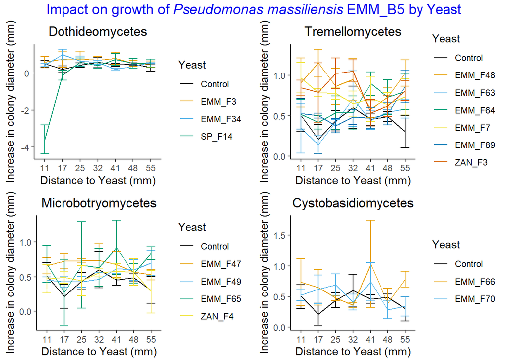

```r
# remove data first data since it is a reference for increase in colony size and donot follow the assumption of linear model i.e. normal distributuion
B5.Day6 <- B5.no.contact[B5.no.contact$DAI == "6",]


plot_listB5 <- list()

# Get unique classes
unique_class <- unique(B5.Day6$Class[B5.Day6$Class != "Control"])

# Loop through each class
for (i in seq_along(unique_class)) {

  # Filter for Control and the current class
  data <- B5.Day6 %>%
    filter(Class %in% c("Control", unique_class[i]))

  # Generate the plot
  p <- ggplot(data, aes(x = distance_to_yeast, y = increase, group = Yeast, color = Yeast)) +
    stat_summary(fun = mean, geom = "line") +
    stat_summary(fun.data = mean_se, geom = "errorbar", width = 0.5) +
    ylab("Increase in colony diameter (mm)") +
    xlab("Distance to Yeast (mm)") +
    theme_classic() +
    scale_color_manual(values = cbbPalette) +
    ggtitle(unique_class[i]) +
    theme(plot.title = element_text(hjust = 0.5))

  # Store the plot
  plot_listB5[[i]] <- p
}

combined_plotB5 <- ggarrange(plotlist = plot_listB5, ncol = 2, nrow = 2, common.legend = FALSE)
# Annotation for the title
final_plotB5 <- annotate_figure(combined_plotB5,
                              top = text_grob(
    expression("Impact on growth of"~italic("Pseudomonas massiliensis")~"EMM_B5 by Yeast"), color = "Blue2", face = "bold", size = 14, hjust = 0.5))

print(final_plotB5)
```

### Stats *Pseudomonas massiliensis* EMM_B5

```r
library(nlme)
B5.no.1st.data <- B5.no.contact[B5.no.contact$DAI != "2",]
B5try <- lme(increase~distance_to_yeast*Yeast*DAI, data = B5.no.1st.data, random = ~1|Replication, na.action = na.omit)
anova(B5try)
```

```
##                             numDF denDF   F-value p-value
## (Intercept)                     1   662 137.37413  <.0001
## distance_to_yeast               6   662   6.86297  <.0001
## Yeast                          15   662  11.45146  <.0001
## DAI                             2   662  17.31295  <.0001
## distance_to_yeast:Yeast        90   662   4.70772  <.0001
## distance_to_yeast:DAI          12   662   1.31193  0.2065
## Yeast:DAI                      30   662   1.83086  0.0048
## distance_to_yeast:Yeast:DAI   180   662   1.42602  0.0010
```

```r
resultsB5=lme(increase~distance_to_yeast*Yeast+Yeast*DAI, data = B5.no.1st.data, random = ~1|Replication, na.action = na.omit)
summary(resultsB5)
```

```
## Linear mixed-effects model fit by REML
##   Data: B5.no.1st.data
##        AIC      BIC    logLik
##   1653.995 2347.826 -680.9974
##
## Random effects:
##  Formula: ~1 | Replication
##         (Intercept)  Residual
## StdDev:  0.07482676 0.4423014
##
## Fixed effects:  increase ~ distance_to_yeast * Yeast + Yeast * DAI
##                                       Value Std.Error  DF   t-value p-value
## (Intercept)                       0.3134921 0.1726661 854  1.815597  0.0698
## distance_to_yeast17              -0.2233333 0.2085029 854 -1.071128  0.2844
## distance_to_yeast25              -0.0533333 0.2085029 854 -0.255792  0.7982
## distance_to_yeast32               0.1033333 0.2085029 854  0.495597  0.6203
## distance_to_yeast41              -0.0166667 0.2085029 854 -0.079935  0.9363
## distance_to_yeast48               0.1000000 0.2085029 854  0.479610  0.6316
## distance_to_yeast55              -0.1111111 0.2085029 854 -0.532900  0.5942
## YeastEMM_F3                      -0.0119048 0.2364201 854 -0.050354  0.9599
## YeastEMM_F34                      0.0419048 0.2364201 854  0.177247  0.8594
## YeastEMM_F47                      0.1971429 0.2364201 854  0.833867  0.4046
## YeastEMM_F48                      0.4533333 0.2364201 854  1.917491  0.0555
## YeastEMM_F49                      0.1271429 0.2364201 854  0.537784  0.5909
## YeastEMM_F63                     -0.0733333 0.2364201 854 -0.310182  0.7565
## YeastEMM_F64                      0.0904762 0.2364201 854  0.382693  0.7020
## YeastEMM_F65                     -0.8681824 0.2467511 854 -3.518454  0.0005
## YeastEMM_F66                      0.2984127 0.2364201 854  1.262214  0.2072
## YeastEMM_F7                       0.4361905 0.2364201 854  1.844981  0.0654
## YeastEMM_F70                      0.0639683 0.2364201 854  0.270570  0.7868
## YeastEMM_F89                      0.1052381 0.2364201 854  0.445132  0.6563
## YeastSP_F14                      -2.3152381 0.2364201 854 -9.792900  0.0000
## YeastZAN_F3                       0.1487302 0.2364201 854  0.629093  0.5295
## YeastZAN_F4                       0.0376190 0.2364201 854  0.159120  0.8736
## DAI6                              0.1457143 0.1364972 854  1.067526  0.2860
## DAI8                              0.2138095 0.1364972 854  1.566402  0.1176
## distance_to_yeast17:YeastEMM_F3   0.4611111 0.2948676 854  1.563790  0.1182
## distance_to_yeast25:YeastEMM_F3   0.3266667 0.2948676 854  1.107842  0.2682
## distance_to_yeast32:YeastEMM_F3   0.0311111 0.2948676 854  0.105509  0.9160
## distance_to_yeast41:YeastEMM_F3   0.3855556 0.2948676 854  1.307555  0.1914
```

[output cut: 6445 more lines]

```
## YeastEMM_F65:DAI8
## YeastEMM_F66:DAI8
## YeastEMM_F7:DAI8
## YeastEMM_F70:DAI8
## YeastEMM_F89:DAI8
## YeastSP_F14:DAI8                  0.500
## YeastZAN_F3:DAI8                  0.500         0.500
## YeastZAN_F4:DAI8                  0.500         0.500        0.500
##
## Standardized Within-Group Residuals:
##           Min            Q1           Med            Q3           Max
## -14.463917335  -0.410039417  -0.006705415   0.383877940   4.218861262
##
## Number of Observations: 1000
## Number of Groups: 3
```

### Loop for running analysis for each day separately EMM_B5

```r
# Unique days
day <- unique(B5.no.1st.data$DAI)
# Initialize empty lists to store results
B5_Day <- list()
meansB5_Day <- list()
resultsB5_Day <- list()
model_summary_B5 <- list()
anova_table_B5 <- list()
Results_lsmeansB5 <- list()
filtered_comparisonsB5 <- list()

for (i in seq_along(day)) {
    # Filter data for the current day
  B5_Day[[i]] <- filter(B5.no.contact, DAI == day[i])
    # Fit the mixed effects model
  resultsB5_Day[[i]] <- lme(increase ~ distance_to_yeast*Yeast,
                            data = B5_Day[[i]],
                            random = ~1 | Replication,
                            na.action = na.omit)
    model_summary_B5[[i]] <- summary(resultsB5_Day[[i]])
  anova_table_B5[[i]] <- anova(resultsB5_Day[[i]])
   # Estimated marginal means
  meansB5_Day[[i]] <- emmeans(resultsB5_Day[[i]], ~ Yeast|distance_to_yeast)
    # Compact letter display with Tukey adjustment
  Results_lsmeansB5[[i]] <- multcomp::cld(meansB5_Day[[i]], alpha = 0.05,
                                          Letters = letters, reversed = TRUE,
                                          details = TRUE)
   # Print lsmeans results
 # print(Results_lsmeansB5[[i]])

  # Filter comparisons involving "Control"
  filtered_comparisonsB5[[i]] <- Results_lsmeansB5[[i]]$comparisons %>%
    filter(grepl("Control", contrast))
   # Print filtered contrasts
  print(filtered_comparisonsB5[[i]])
}
```

```
## distance_to_yeast = 11:
##  contrast          estimate    SE  df t.ratio p.value
##  Control - SP_F14   0.80667 0.258 222   3.130  0.1286
##  Control - EMM_F3   0.03333 0.258 222   0.129  1.0000
##  ZAN_F3 - Control   0.06000 0.258 222   0.233  1.0000
##  ZAN_F4 - Control   0.06333 0.258 222   0.246  1.0000
##  EMM_F70 - Control  0.09000 0.258 222   0.349  1.0000
##  EMM_F63 - Control  0.09333 0.258 222   0.362  1.0000
##  EMM_F34 - Control  0.15333 0.258 222   0.595  1.0000
##  EMM_F64 - Control  0.16667 0.258 222   0.647  1.0000
##  EMM_F49 - Control  0.17333 0.258 222   0.673  1.0000
##  EMM_F65 - Control  0.18333 0.258 222   0.711  1.0000
##  EMM_F89 - Control  0.21333 0.258 222   0.828  1.0000
##  EMM_F47 - Control  0.23333 0.258 222   0.905  0.9999
##  EMM_F66 - Control  0.32000 0.258 222   1.242  0.9973
##  EMM_F7 - Control   0.39333 0.258 222   1.526  0.9783
##  EMM_F48 - Control  0.51000 0.258 222   1.979  0.8341
##
## distance_to_yeast = 17:
##  contrast          estimate    SE  df t.ratio p.value
##  Control - EMM_F63  0.29000 0.258 222   1.125  0.9991
##  Control - SP_F14   0.12667 0.258 222   0.492  1.0000
##  Control - EMM_F49  0.01333 0.258 222   0.052  1.0000
##  EMM_F64 - Control  0.12333 0.258 222   0.479  1.0000
##  EMM_F89 - Control  0.14667 0.258 222   0.569  1.0000
##  ZAN_F3 - Control   0.19667 0.258 222   0.763  1.0000
##  EMM_F47 - Control  0.24667 0.258 222   0.957  0.9999
##  ZAN_F4 - Control   0.26333 0.258 222   1.022  0.9997
##  EMM_F7 - Control   0.27000 0.258 222   1.048  0.9996
##  EMM_F70 - Control  0.29667 0.258 222   1.151  0.9988
##  EMM_F34 - Control  0.37667 0.258 222   1.462  0.9856
##  EMM_F66 - Control  0.38667 0.258 222   1.500  0.9815
##  EMM_F3 - Control   0.43000 0.258 222   1.669  0.9527
##  EMM_F65 - Control  0.59333 0.258 222   2.302  0.6223
##  EMM_F48 - Control  0.68333 0.258 222   2.652  0.3689
##
## distance_to_yeast = 25:
##  contrast          estimate    SE  df t.ratio p.value
##  Control - SP_F14   0.16667 0.258 222   0.647  1.0000
##  Control - ZAN_F4   0.07000 0.258 222   0.272  1.0000
```

[output cut: 329 more lines]

```
##  Control - ZAN_F4   0.00667 0.432 215   0.015  1.0000
##  ZAN_F3 - Control   0.01333 0.432 215   0.031  1.0000
##  EMM_F66 - Control  0.11000 0.432 215   0.254  1.0000
##  EMM_F34 - Control  0.13000 0.432 215   0.301  1.0000
##  EMM_F63 - Control  0.18000 0.432 215   0.416  1.0000
##  EMM_F3 - Control   0.30000 0.432 215   0.694  1.0000
##  EMM_F89 - Control  0.31333 0.432 215   0.725  1.0000
##  SP_F14 - Control   0.33333 0.432 215   0.771  1.0000
##  EMM_F65 - Control  0.39009 0.484 215   0.806  1.0000
##  EMM_F48 - Control  0.43000 0.432 215   0.995  0.9998
##  EMM_F49 - Control  0.43667 0.432 215   1.010  0.9998
##  EMM_F64 - Control  0.50333 0.432 215   1.164  0.9987
##
## Degrees-of-freedom method: containment
## P value adjustment: tukey method for comparing a family of 16 estimates
```

## *Xanthomonas perforans* AL65

```r
#read data
AL65 <- read.csv("CoCultureAssay/CoCultureAssayData/2024-08-09_PeaceAssay_AL65.csv", na.strings = "na")
#load cbb color palette
cbbPalette <- c("#000000", "#E69F00", "#56B4E9", "#009E73", "#F0E442", "#0072B2", "#D55E00", "#CC79A7")
str(AL65)
```

```
## 'data.frame':    1152 obs. of  8 variables:
##  $ Bacteria         : chr  "AL65" "AL65" "AL65" "AL65" ...
##  $ Yeast            : chr  "EMM_F3" "EMM_F3" "EMM_F3" "EMM_F3" ...
##  $ Class            : chr  "Dothideomycetes" "Dothideomycetes" "Dothideomycetes" "Dothideomycetes" ...
##  $ Replication      : int  1 1 1 1 1 1 1 1 2 2 ...
##  $ DAI              : int  2 2 2 2 2 2 2 2 2 2 ...
##  $ distance_to_yeast: num  0 11.4 17.4 24.9 31.8 ...
##  $ colony_diameter  : num  7.59 8.92 8.31 9.43 9.37 9.69 9.59 7.61 7.81 9.39 ...
##  $ increase         : num  0 0 0 0 0 0 0 0 0 0 ...
```

```r
#round off of the distance to yeast so that it is visibly a categorical variable
AL65$distance_to_yeast <- round(AL65$distance_to_yeast, 0)
#change into categorical dataset
AL65$Replication=as.factor(AL65$Replication)
AL65$Yeast=as.factor(AL65$Yeast)
AL65$DAI=as.factor(AL65$DAI)
AL65$distance_to_yeast=as.factor(AL65$distance_to_yeast)

#remove the data for the distance zero
AL65.no.contact <- AL65[AL65$distance_to_yeast != 0, ]
head(AL65.no.contact)
```

```
##   Bacteria  Yeast           Class Replication DAI distance_to_yeast
## 2     AL65 EMM_F3 Dothideomycetes           1   2                11
## 3     AL65 EMM_F3 Dothideomycetes           1   2                17
## 4     AL65 EMM_F3 Dothideomycetes           1   2                25
## 5     AL65 EMM_F3 Dothideomycetes           1   2                32
## 6     AL65 EMM_F3 Dothideomycetes           1   2                41
## 7     AL65 EMM_F3 Dothideomycetes           1   2                48
##   colony_diameter increase
## 2            8.92        0
## 3            8.31        0
## 4            9.43        0
## 5            9.37        0
## 6            9.69        0
## 7            9.59        0
```

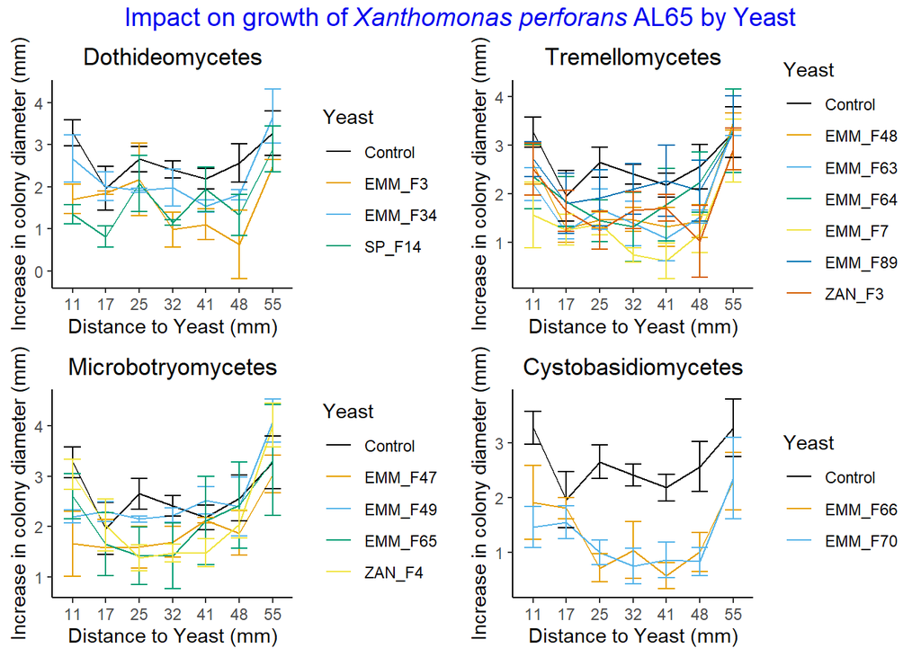

```r
# remove data first data since it is a reference for increase in colony size and donot follow the assumption of linear model i.e. normal distribution
AL65.no.1st.data <- AL65.no.contact[AL65.no.contact$DAI != "2",]

#Using Day 6th data for plot
AL65.Day6 <- AL65.no.contact[AL65.no.contact$DAI == "6",]


plot_listAL65 <- list()

# Get unique classes
unique_class <- unique(AL65.Day6$Class[AL65.Day6$Class != "Control"])

# Loop through each class
for (i in seq_along(unique_class)) {

  # Filter for Control and the current class
  data <- AL65.Day6 %>%
    filter(Class %in% c("Control", unique_class[i]))

  # Generate the plot
  p <- ggplot(data, aes(x = distance_to_yeast, y = increase, group = Yeast, color = Yeast)) +
    stat_summary(fun = mean, geom = "line") +
    stat_summary(fun.data = mean_se, geom = "errorbar", width = 0.5) +
    ylab("Increase in colony diameter (mm)") +
    xlab("Distance to Yeast (mm)") +
    theme_classic() +
    scale_color_manual(values = cbbPalette) +
    ggtitle(unique_class[i]) +
    theme(plot.title = element_text(hjust = 0.5))

  # Store the plot
  plot_listAL65[[i]] <- p
}

combined_plotAL65 <- ggarrange(plotlist = plot_listAL65, ncol = 2, nrow = 2, common.legend = FALSE)
# Annotation for the title
final_plotAL65 <- annotate_figure(combined_plotAL65,
                               top = text_grob(
    expression("Impact on growth of"~italic("Xanthomonas perforans")~"AL65 by Yeast"), face = "bold", color = "Blue2", size = 14, hjust = 0.5))

print(final_plotAL65)
```

### Stats for *Xanthomonas perforans* AL65

```r
AL65.no.1st.data <- AL65.no.contact[AL65.no.contact$DAI != "2",]
AL65try <- lme(increase~DAI*distance_to_yeast*Yeast, data = AL65.no.1st.data, random = ~1|Replication, na.action = na.omit)
anova(AL65try)
```

```
##                             numDF denDF   F-value p-value
## (Intercept)                     1   432 2055.0847  <.0001
## DAI                             1   432  173.8503  <.0001
## distance_to_yeast               6   432   39.7946  <.0001
## Yeast                          15   432   10.2336  <.0001
## DAI:distance_to_yeast           6   432    3.1804  0.0046
## DAI:Yeast                      15   432    1.2641  0.2213
## distance_to_yeast:Yeast        90   432    0.8570  0.8130
## DAI:distance_to_yeast:Yeast    90   432    0.3007  1.0000
```

```r
resultsAL65=lme(increase~DAI*distance_to_yeast+Yeast, data = AL65.no.1st.data, random = ~1|Replication, na.action = na.omit)
summary(resultsAL65)
```

```
## Linear mixed-effects model fit by REML
##   Data: AL65.no.1st.data
##        AIC      BIC    logLik
##   1499.279 1637.047 -718.6393
##
## Random effects:
##  Formula: ~1 | Replication
##         (Intercept)  Residual
## StdDev:  0.03467616 0.6962705
##
## Fixed effects:  increase ~ DAI * distance_to_yeast + Yeast
##                               Value Std.Error  DF   t-value p-value
## (Intercept)               2.1376640 0.1656037 627 12.908312  0.0000
## DAI6                      0.8274468 0.1436296 627  5.760975  0.0000
## distance_to_yeast17      -0.4557447 0.1436296 627 -3.173054  0.0016
## distance_to_yeast25      -0.5238298 0.1436296 627 -3.647087  0.0003
## distance_to_yeast32      -0.5140426 0.1436296 627 -3.578945  0.0004
## distance_to_yeast41      -0.4525532 0.1436296 627 -3.150834  0.0017
## distance_to_yeast48      -0.2368085 0.1436296 627 -1.648744  0.0997
## distance_to_yeast55       0.4568085 0.1436296 627  3.180461  0.0015
## YeastEMM_F3              -1.1768940 0.1702600 627 -6.912333  0.0000
## YeastEMM_F34             -0.4518940 0.1702600 627 -2.654140  0.0082
## YeastEMM_F47             -0.9447511 0.1702600 627 -5.548872  0.0000
## YeastEMM_F48             -0.8449892 0.1702600 627 -4.962933  0.0000
## YeastEMM_F49             -0.1340368 0.1702600 627 -0.787248  0.4314
## YeastEMM_F63             -0.7097511 0.1702600 627 -4.168630  0.0000
## YeastEMM_F64             -0.5114178 0.1702600 627 -3.003745  0.0028
## YeastEMM_F65             -0.7392749 0.1702600 627 -4.342034  0.0000
## YeastEMM_F66             -1.1287987 0.1702600 627 -6.629852  0.0000
## YeastEMM_F7              -1.2259416 0.1702600 627 -7.200407  0.0000
## YeastEMM_F70             -1.2047511 0.1702600 627 -7.075948  0.0000
## YeastEMM_F89             -0.4361797 0.1702600 627 -2.561844  0.0106
## YeastSP_F14              -0.9454654 0.1702600 627 -5.553067  0.0000
## YeastZAN_F3              -0.8773702 0.1702600 627 -5.153119  0.0000
## YeastZAN_F4              -0.3764178 0.1702600 627 -2.210841  0.0274
## DAI6:distance_to_yeast17 -0.1038298 0.2031230 627 -0.511167  0.6094
## DAI6:distance_to_yeast25 -0.0744681 0.2031230 627 -0.366616  0.7140
## DAI6:distance_to_yeast32 -0.2338298 0.2031230 627 -1.151173  0.2501
## DAI6:distance_to_yeast41 -0.1991489 0.2031230 627 -0.980435  0.3272
## DAI6:distance_to_yeast48 -0.3491489 0.2031230 627 -1.718904  0.0861
```

[output cut: 139 more lines]

```
## YeastZAN_F3
## YeastZAN_F4
## DAI6:distance_to_yeast17
## DAI6:distance_to_yeast25
## DAI6:distance_to_yeast32
## DAI6:distance_to_yeast41  0.500
## DAI6:distance_to_yeast48  0.500    0.500
## DAI6:distance_to_yeast55  0.500    0.500     0.500
##
## Standardized Within-Group Residuals:
##         Min          Q1         Med          Q3         Max
## -2.94348467 -0.63846992 -0.05708579  0.69410830  3.76818192
##
## Number of Observations: 658
## Number of Groups: 3
```

```r
anova(resultsAL65)
```

```
##                       numDF denDF   F-value p-value
## (Intercept)               1   627 2040.8903  <.0001
## DAI                       1   627  196.3521  <.0001
## distance_to_yeast         6   627   44.9453  <.0001
## Yeast                    15   627   11.5368  <.0001
## DAI:distance_to_yeast     6   627    3.5921  0.0016
```

### Loop for running analysis for each day separately for AL65

```r
# Unique days
day <- unique(AL65.no.1st.data$DAI)
# Initialize empty lists to store results
AL65_Day <- list()
meansAL65_Day <- list()
resultsAL65_Day <- list()
model_summary_AL65 <- list()
anova_table_AL65 <- list()
Results_lsmeansAL65 <- list()
filtered_comparisonsAL65 <- list()

for (i in seq_along(day)) {
    # Filter data for the current day
  AL65_Day[[i]] <- filter(AL65.no.1st.data, DAI == day[i])
    # Fit the mixed effects model
  resultsAL65_Day[[i]] <- lme(increase ~ distance_to_yeast+Yeast,
                            data = AL65_Day[[i]],
                            random = ~1 | Replication,
                            na.action = na.omit)
    model_summary_AL65[[i]] <- summary(resultsAL65_Day[[i]])
  anova_table_AL65[[i]] <- anova(resultsAL65_Day[[i]])
   # Estimated marginal means
  meansAL65_Day[[i]] <- emmeans(resultsAL65_Day[[i]], ~ Yeast | distance_to_yeast)
    # Compact letter display with Tukey adjustment
  Results_lsmeansAL65[[i]] <- multcomp::cld(meansAL65_Day[[i]], alpha = 0.05,
                                          Letters = letters, reversed = TRUE,
                                          details = TRUE)
   # Print lsmeans results
  #print(Results_lsmeansAL65[[i]])

  # Filter comparisons involving "Control"
  filtered_comparisonsAL65[[i]] <- Results_lsmeansAL65[[i]]$comparisons %>%
    filter(grepl("Control", contrast))
   # Print filtered contrasts
  print(filtered_comparisonsAL65[[i]])
}
```

```
## distance_to_yeast = 11:
##  contrast          estimate    SE  df t.ratio p.value
##  Control - EMM_F3     1.315 0.213 305   6.173  <.0001
##  Control - EMM_F7     1.229 0.213 305   5.771  <.0001
##  Control - EMM_F47    1.223 0.213 305   5.740  <.0001
##  Control - EMM_F70    1.060 0.213 305   4.975  0.0001
##  Control - EMM_F65    1.010 0.213 305   4.743  0.0004
##  Control - EMM_F66    0.986 0.213 305   4.629  0.0006
##  Control - ZAN_F3     0.973 0.213 305   4.566  0.0008
##  Control - EMM_F48    0.958 0.213 305   4.499  0.0010
##  Control - SP_F14     0.937 0.213 305   4.398  0.0016
##  Control - EMM_F63    0.599 0.213 305   2.813  0.2673
##  Control - EMM_F89    0.575 0.213 305   2.699  0.3360
##  Control - EMM_F34    0.526 0.213 305   2.471  0.4958
##  Control - EMM_F64    0.462 0.213 305   2.169  0.7178
##  Control - ZAN_F4     0.354 0.213 305   1.662  0.9549
##  Control - EMM_F49    0.218 0.213 305   1.023  0.9997
##
## distance_to_yeast = 17:
##  contrast          estimate    SE  df t.ratio p.value
##  Control - EMM_F3     1.315 0.213 305   6.173  <.0001
##  Control - EMM_F7     1.229 0.213 305   5.771  <.0001
##  Control - EMM_F47    1.223 0.213 305   5.740  <.0001
##  Control - EMM_F70    1.060 0.213 305   4.975  0.0001
##  Control - EMM_F65    1.010 0.213 305   4.743  0.0004
##  Control - EMM_F66    0.986 0.213 305   4.629  0.0006
##  Control - ZAN_F3     0.973 0.213 305   4.566  0.0008
##  Control - EMM_F48    0.958 0.213 305   4.499  0.0010
##  Control - SP_F14     0.937 0.213 305   4.398  0.0016
##  Control - EMM_F63    0.599 0.213 305   2.813  0.2673
##  Control - EMM_F89    0.575 0.213 305   2.699  0.3360
##  Control - EMM_F34    0.526 0.213 305   2.471  0.4958
##  Control - EMM_F64    0.462 0.213 305   2.169  0.7178
##  Control - ZAN_F4     0.354 0.213 305   1.662  0.9549
##  Control - EMM_F49    0.218 0.213 305   1.023  0.9997
##
## distance_to_yeast = 25:
##  contrast          estimate    SE  df t.ratio p.value
##  Control - EMM_F3     1.315 0.213 305   6.173  <.0001
##  Control - EMM_F7     1.229 0.213 305   5.771  <.0001
```

[output cut: 201 more lines]

```
##  Control - EMM_F3    1.0271 0.263 305   3.910  0.0108
##  Control - SP_F14    0.9423 0.263 305   3.587  0.0329
##  Control - EMM_F63   0.8085 0.263 305   3.078  0.1446
##  Control - ZAN_F3    0.7704 0.263 305   2.933  0.2054
##  Control - EMM_F48   0.7199 0.263 305   2.741  0.3101
##  Control - EMM_F47   0.6552 0.263 305   2.494  0.4789
##  Control - EMM_F64   0.5490 0.263 305   2.090  0.7703
##  Control - EMM_F65   0.4566 0.263 305   1.738  0.9350
##  Control - ZAN_F4    0.3871 0.263 305   1.473  0.9847
##  Control - EMM_F34   0.3656 0.263 305   1.392  0.9913
##  Control - EMM_F89   0.2856 0.263 305   1.087  0.9994
##  Control - EMM_F49   0.0385 0.263 305   0.147  1.0000
##
## Degrees-of-freedom method: containment
## P value adjustment: tukey method for comparing a family of 16 estimates
```

## *Hymenobacter polaris* EMM_B17

```r
#read data
B17 <- read.csv("CoCultureAssay/CoCultureAssayData/2024-07-17_PeaceAssay_B17.csv", na.strings = "na")


#load cbb color palette
cbbPalette <- c("#000000", "#E69F00", "#56B4E9", "#009E73", "#F0E442", "#0072B2", "#D55E00", "#CC79A7")
str(B17)
```

```
## 'data.frame':    1536 obs. of  9 variables:
##  $ Bacteria               : chr  "B17" "B17" "B17" "B17" ...
##  $ Yeast                  : chr  "EMM_F3" "EMM_F3" "EMM_F3" "EMM_F3" ...
##  $ Class                  : chr  "Dothideomycetes" "Dothideomycetes" "Dothideomycetes" "Dothideomycetes" ...
##  $ Replication            : int  1 1 1 1 1 1 1 1 2 2 ...
##  $ DAI                    : int  2 2 2 2 2 2 2 2 2 2 ...
##  $ distance_to_yeast      : num  0 11.4 17.4 24.9 31.8 ...
##  $ colony_diameter        : num  6.88 6.88 7.32 6.87 7.16 7.09 7.09 6.92 7.98 7.03 ...
##  $ colony_diameter_control: num  7.79 7.79 7.79 7.79 7.52 6.98 7.67 7.67 6.19 7.31 ...
##  $ increase               : num  0 0 0 0 0 0 0 0 0 0 ...
```

```r
#round off of the distance to yeast so that it is visibly a categorical variable
B17$distance_to_yeast <- round(B17$distance_to_yeast, 0)
#change into categorical dataset
B17$Replication=as.factor(B17$Replication)
B17$Yeast=as.factor(B17$Yeast)
B17$DAI=as.factor(B17$DAI)
B17$distance_to_yeast=as.factor(B17$distance_to_yeast)

#remove the data for the distance zero
B17.no.contact <- B17[B17$distance_to_yeast != 0, ]
head(B17.no.contact)
```

```
##   Bacteria  Yeast           Class Replication DAI distance_to_yeast
## 2      B17 EMM_F3 Dothideomycetes           1   2                11
## 3      B17 EMM_F3 Dothideomycetes           1   2                17
## 4      B17 EMM_F3 Dothideomycetes           1   2                25
## 5      B17 EMM_F3 Dothideomycetes           1   2                32
## 6      B17 EMM_F3 Dothideomycetes           1   2                41
## 7      B17 EMM_F3 Dothideomycetes           1   2                48
##   colony_diameter colony_diameter_control increase
## 2            6.88                    7.79        0
## 3            7.32                    7.79        0
## 4            6.87                    7.79        0
## 5            7.16                    7.52        0
## 6            7.09                    6.98        0
## 7            7.09                    7.67        0
```

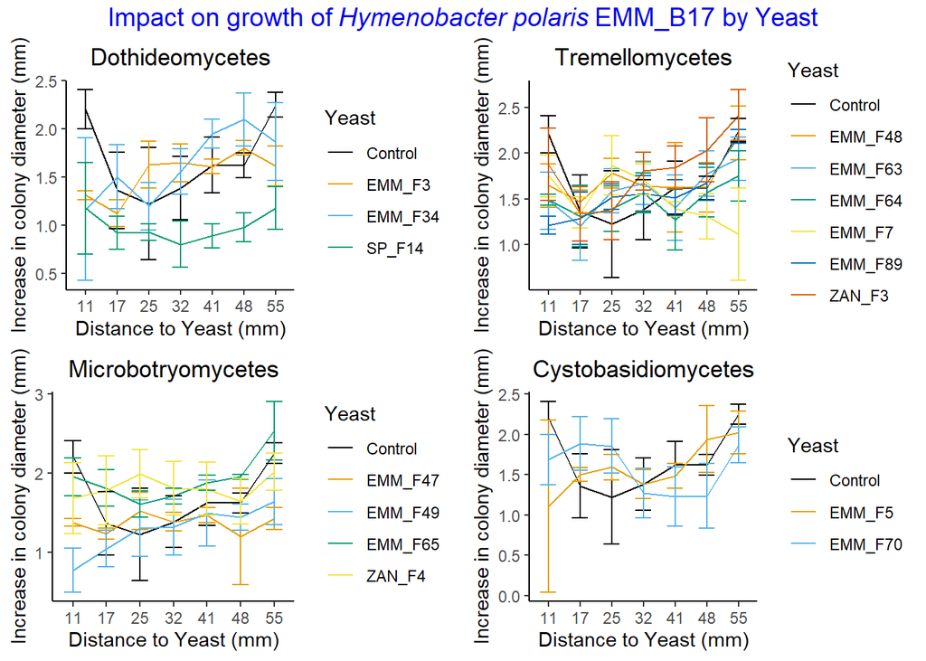

```r
# remove data first data since it is a reference for increase in colony size and donot follow the assumption of linear model i.e. normal distributuion
B17.Day6 <- B17.no.contact[B17.no.contact$DAI == "6",]


plot_listB17 <- list()

# Get unique classes
unique_class <- unique(B17.Day6$Class[B17.Day6$Class != "Control"])

# Loop through each class
for (i in seq_along(unique_class)) {

  # Filter for Control and the current class
  data <- B17.Day6 %>%
    filter(Class %in% c("Control", unique_class[i]))

  # Generate the plot
  p <- ggplot(data, aes(x = distance_to_yeast, y = increase, group = Yeast, color = Yeast)) +
    stat_summary(fun = mean, geom = "line") +
    stat_summary(fun.data = mean_se, geom = "errorbar", width = 0.5) +
    ylab("Increase in colony diameter (mm)") +
    xlab("Distance to Yeast (mm)") +
    theme_classic() +
    scale_color_manual(values = cbbPalette) +
    ggtitle(unique_class[i]) +
    theme(plot.title = element_text(hjust = 0.5))

  # Store the plot
  plot_listB17[[i]] <- p
}

combined_plotB17 <- ggarrange(plotlist = plot_listB17, ncol = 2, nrow = 2, common.legend = FALSE)
# Annotation for the title
final_plotB17 <- annotate_figure(combined_plotB17,
                                top = text_grob(
    expression("Impact on growth of"~italic("Hymenobacter polaris")~"EMM_B17 by Yeast"), face = "bold", color = "Blue2", size = 14, hjust = 0.5))

print(final_plotB17)
```

### Stats for *Hymenobacter polaris* EMM_B17

```r
B17.no.1st.data <- B17.no.contact[B17.no.contact$DAI != "2",]
B17try <- lme(increase~DAI*distance_to_yeast*Yeast, data = B17.no.1st.data, random = ~1|Replication, na.action = na.omit)
anova(B17try)
```

```
##                             numDF denDF   F-value p-value
## (Intercept)                     1   649 1042.6016  <.0001
## DAI                             2   649  187.9019  <.0001
## distance_to_yeast               6   649    9.5336  <.0001
## Yeast                          15   649    9.0201  <.0001
## DAI:distance_to_yeast          12   649    0.8551  0.5932
## DAI:Yeast                      30   649    1.0345  0.4172
## distance_to_yeast:Yeast        90   649    1.4769  0.0045
## DAI:distance_to_yeast:Yeast   180   649    0.1830  1.0000
```

```r
resultsB17=lme(increase~DAI+distance_to_yeast*Yeast, data = B17.no.1st.data, random = ~1|Replication, na.action = na.omit)
summary(resultsB17)
```

```
## Linear mixed-effects model fit by REML
##   Data: B17.no.1st.data
##        AIC      BIC    logLik
##   1651.797 2205.341 -709.8983
##
## Random effects:
##  Formula: ~1 | Replication
##         (Intercept)  Residual
## StdDev:   0.0769858 0.4706221
##
## Fixed effects:  increase ~ DAI + distance_to_yeast * Yeast
##                                       Value Std.Error  DF   t-value p-value
## (Intercept)                       1.5623978 0.1644198 871  9.502492  0.0000
## DAI6                              0.4599392 0.0366935 871 12.534617  0.0000
## DAI8                              0.7762006 0.0366935 871 21.153617  0.0000
## distance_to_yeast17              -0.7800000 0.2218534 871 -3.515836  0.0005
## distance_to_yeast25              -0.7111111 0.2218534 871 -3.205320  0.0014
## distance_to_yeast32              -0.4877778 0.2218534 871 -2.198649  0.0282
## distance_to_yeast41              -0.3866667 0.2218534 871 -1.742893  0.0817
## distance_to_yeast48              -0.3322222 0.2218534 871 -1.497486  0.1346
## distance_to_yeast55               0.1255556 0.2218534 871  0.565939  0.5716
## YeastEMM_F3                      -0.6755556 0.2218534 871 -3.045054  0.0024
## YeastEMM_F34                     -0.8166667 0.2218534 871 -3.681110  0.0002
## YeastEMM_F47                     -0.5877778 0.2218534 871 -2.649397  0.0082
## YeastEMM_F48                     -0.4155556 0.2218534 871 -1.873109  0.0614
## YeastEMM_F49                     -1.4166667 0.2218534 871 -6.385599  0.0000
## YeastEMM_F5                      -0.8633333 0.2218534 871 -3.891459  0.0001
## YeastEMM_F63                     -0.4833333 0.2218534 871 -2.178616  0.0296
## YeastEMM_F64                     -0.5355556 0.2218534 871 -2.414007  0.0160
## YeastEMM_F65                     -0.2466667 0.2218534 871 -1.111845  0.2665
## YeastEMM_F7                      -0.2771202 0.2482507 871 -1.116292  0.2646
## YeastEMM_F70                     -0.4033333 0.2218534 871 -1.818018  0.0694
## YeastEMM_F89                     -0.7133333 0.2218534 871 -3.215337  0.0014
## YeastSP_F14                      -0.8888889 0.2218534 871 -4.006650  0.0001
## YeastZAN_F3                      -0.2177778 0.2218534 871 -0.981629  0.3266
## YeastZAN_F4                      -0.4277778 0.2218534 871 -1.928200  0.0542
## distance_to_yeast17:YeastEMM_F3   0.7644444 0.3137481 871  2.436491  0.0150
## distance_to_yeast25:YeastEMM_F3   1.0433333 0.3137481 871  3.325386  0.0009
## distance_to_yeast32:YeastEMM_F3   0.8088889 0.3137481 871  2.578148  0.0101
## distance_to_yeast41:YeastEMM_F3   0.7122222 0.3137481 871  2.270045  0.0234
```

[output cut: 3955 more lines]

```
## distance_to_yeast48:YeastZAN_F3
## distance_to_yeast55:YeastZAN_F3
## distance_to_yeast17:YeastZAN_F4
## distance_to_yeast25:YeastZAN_F4
## distance_to_yeast32:YeastZAN_F4
## distance_to_yeast41:YeastZAN_F4
## distance_to_yeast48:YeastZAN_F4   0.500
## distance_to_yeast55:YeastZAN_F4   0.500         0.500
##
## Standardized Within-Group Residuals:
##          Min           Q1          Med           Q3          Max
## -4.887204324 -0.566252239 -0.002177437  0.604449129  3.337324837
##
## Number of Observations: 987
## Number of Groups: 3
```

```r
#Anova(resultsB5)
anova(resultsB17)
```

```
##                         numDF denDF   F-value p-value
## (Intercept)                 1   871 1042.2003  <.0001
## DAI                         2   871  226.2931  <.0001
## distance_to_yeast           6   871   11.4815  <.0001
## Yeast                      15   871   10.8649  <.0001
## distance_to_yeast:Yeast    90   871    1.7787  <.0001
```

### Loop for running analysis for each day separately for EMM_B17

```r
# Unique days
day <- unique(B17.no.1st.data$DAI)
# Initialize empty lists to store results
B17_Day <- list()
meansB17_Day <- list()
resultsB17_Day <- list()
model_summary_B17 <- list()
anova_table_B17 <- list()
Results_lsmeansB17 <- list()
filtered_comparisonsB17 <- list()

for (i in seq_along(day)) {
    # Filter data for the current day
  B17_Day[[i]] <- filter(B17.no.1st.data, DAI == day[i])
    # Fit the mixed effects model
  resultsB17_Day[[i]] <- lme(increase ~ distance_to_yeast * Yeast,
                            data = B17_Day[[i]],
                            random = ~1 | Replication,
                            na.action = na.omit)
    model_summary_B17[[i]] <- summary(resultsB17_Day[[i]])
  anova_table_B17[[i]] <- anova(resultsB17_Day[[i]])
   # Estimated marginal means
  meansB17_Day[[i]] <- emmeans(resultsB17_Day[[i]], ~ Yeast | distance_to_yeast)
    # Compact letter display with Tukey adjustment
  Results_lsmeansB17[[i]] <- multcomp::cld(meansB17_Day[[i]], alpha = 0.05,
                                          Letters = letters, reversed = TRUE,
                                          details = TRUE)
   # Print lsmeans results
  #print(Results_lsmeansB17[[i]])

  # Filter comparisons involving "Control"
  filtered_comparisonsB17[[i]] <- Results_lsmeansB17[[i]]$comparisons %>%
    filter(grepl("Control", contrast))
   # Print filtered contrasts
  print(filtered_comparisonsB17[[i]])
}
```

```
## distance_to_yeast = 11:
##  contrast          estimate    SE  df t.ratio p.value
##  Control - EMM_F49  1.53000 0.424 215   3.608  0.0322
##  Control - EMM_F5   0.69000 0.424 215   1.627  0.9617
##  Control - EMM_F64  0.59333 0.424 215   1.399  0.9906
##  Control - EMM_F89  0.57000 0.424 215   1.344  0.9937
##  Control - EMM_F34  0.39000 0.424 215   0.920  0.9999
##  Control - EMM_F3   0.31333 0.424 215   0.739  1.0000
##  Control - EMM_F7   0.29025 0.474 215   0.612  1.0000
##  Control - ZAN_F4   0.26667 0.424 215   0.629  1.0000
##  Control - EMM_F65  0.24333 0.424 215   0.574  1.0000
##  Control - EMM_F70  0.24000 0.424 215   0.566  1.0000
##  Control - EMM_F63  0.23000 0.424 215   0.542  1.0000
##  Control - EMM_F48  0.22333 0.424 215   0.527  1.0000
##  Control - SP_F14   0.19667 0.424 215   0.464  1.0000
##  Control - EMM_F47  0.14333 0.424 215   0.338  1.0000
##  Control - ZAN_F3   0.04667 0.424 215   0.110  1.0000
##
## distance_to_yeast = 17:
##  contrast          estimate    SE  df t.ratio p.value
##  EMM_F49 - Control  0.08667 0.424 215   0.204  1.0000
##  EMM_F65 - Control  0.12667 0.424 215   0.299  1.0000
##  EMM_F89 - Control  0.17000 0.424 215   0.401  1.0000
##  ZAN_F3 - Control   0.17667 0.424 215   0.417  1.0000
##  ZAN_F4 - Control   0.22000 0.424 215   0.519  1.0000
##  EMM_F64 - Control  0.29667 0.424 215   0.700  1.0000
##  SP_F14 - Control   0.32000 0.424 215   0.755  1.0000
##  EMM_F70 - Control  0.32333 0.424 215   0.762  1.0000
##  EMM_F47 - Control  0.37000 0.424 215   0.872  1.0000
##  EMM_F48 - Control  0.37667 0.424 215   0.888  1.0000
##  EMM_F7 - Control   0.38975 0.474 215   0.822  1.0000
##  EMM_F63 - Control  0.41333 0.424 215   0.975  0.9998
##  EMM_F5 - Control   0.45667 0.424 215   1.077  0.9995
##  EMM_F3 - Control   0.53333 0.424 215   1.258  0.9969
##  EMM_F34 - Control  0.57667 0.424 215   1.360  0.9929
##
## distance_to_yeast = 25:
##  contrast          estimate    SE  df t.ratio p.value
##  SP_F14 - Control   0.05000 0.424 215   0.118  1.0000
##  EMM_F65 - Control  0.25000 0.424 215   0.589  1.0000
```

[output cut: 329 more lines]

```
##  Control - EMM_F3   0.80667 0.430 215   1.878  0.8831
##  Control - EMM_F47  0.70667 0.430 215   1.645  0.9579
##  Control - EMM_F64  0.68333 0.430 215   1.591  0.9685
##  Control - ZAN_F4   0.62000 0.430 215   1.443  0.9872
##  Control - EMM_F34  0.50333 0.430 215   1.172  0.9986
##  Control - EMM_F5   0.46333 0.430 215   1.079  0.9995
##  Control - EMM_F48  0.32333 0.430 215   0.753  1.0000
##  Control - EMM_F70  0.32333 0.430 215   0.753  1.0000
##  Control - EMM_F63  0.31000 0.430 215   0.722  1.0000
##  Control - EMM_F89  0.29333 0.430 215   0.683  1.0000
##  Control - ZAN_F3   0.15000 0.430 215   0.349  1.0000
##  Control - EMM_F65  0.04000 0.430 215   0.093  1.0000
##
## Degrees-of-freedom method: containment
## P value adjustment: tukey method for comparing a family of 16 estimates
```

## *Methylobacterium platani* EMM_B52

```r
#read data
B52 <- read.csv("CoCultureAssay/CoCultureAssayData/MergedB52.csv", na.strings = "na")
#load cbb color palette
cbbPalette <- c("#000000", "#E69F00", "#56B4E9", "#009E73", "#F0E442", "#0072B2", "#D55E00", "#CC79A7")
str(B52)
```

```
## 'data.frame':    1728 obs. of  9 variables:
##  $ Bacteria               : chr  "B52" "B52" "B52" "B52" ...
##  $ Yeast                  : chr  "EMM_F3" "EMM_F3" "EMM_F3" "EMM_F3" ...
##  $ Class                  : chr  "Dothideomycetes" "Dothideomycetes" "Dothideomycetes" "Dothideomycetes" ...
##  $ Replication            : int  1 1 1 1 1 1 1 1 2 2 ...
##  $ DAI                    : int  2 2 2 2 2 2 2 2 2 2 ...
##  $ distance_to_yeast      : num  0 11.4 17.4 24.9 31.8 ...
##  $ colony_diameter        : num  6.21 5.75 5.75 6.15 5.39 6.14 6.39 6.39 6.33 6.33 ...
##  $ colony_diameter_control: num  6.34 5.63 5.67 8.45 7.26 6.88 7.6 6.69 7.01 7.02 ...
##  $ increase               : num  0 0 0 0 0 0 0 0 0 0 ...
```

```r
#round off of the distance to yeast so that it is visibly a categorical variable
B52$distance_to_yeast <- round(B52$distance_to_yeast, 0)
#change into categorical dataset
B52$Replication=as.factor(B52$Replication)
B52$Yeast=as.factor(B52$Yeast)
B52$DAI=as.factor(B52$DAI)
B52$distance_to_yeast=as.factor(B52$distance_to_yeast)

#remove the data for the distance zero
B52.no.contact <- B52[B52$distance_to_yeast != 0, ]
head(B52.no.contact)
```

```
##   Bacteria  Yeast           Class Replication DAI distance_to_yeast
## 2      B52 EMM_F3 Dothideomycetes           1   2                11
## 3      B52 EMM_F3 Dothideomycetes           1   2                17
## 4      B52 EMM_F3 Dothideomycetes           1   2                25
## 5      B52 EMM_F3 Dothideomycetes           1   2                32
## 6      B52 EMM_F3 Dothideomycetes           1   2                41
## 7      B52 EMM_F3 Dothideomycetes           1   2                48
##   colony_diameter colony_diameter_control increase
## 2            5.75                    5.63        0
## 3            5.75                    5.67        0
## 4            6.15                    8.45        0
## 5            5.39                    7.26        0
## 6            6.14                    6.88        0
## 7            6.39                    7.60        0
```

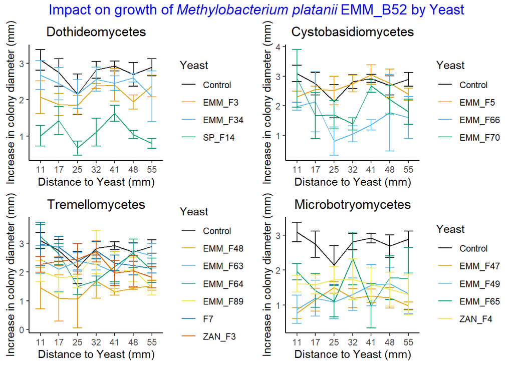

```r
# remove data first data since it is a reference for increase in colony size and donot follow the assumption of linear model i.e. normal distribution
B52.no.1st.data <- B52.no.contact[B52.no.contact$DAI != "2",]

#for plot purposes we used Day 6 data
B52.Day6 <- B52.no.contact[B52.no.contact$DAI == "6",]


plot_listB52 <- list()

# Get unique classes
unique_class <- unique(B52.Day6$Class[B52.Day6$Class != "Control"])

# Loop through each class
for (i in seq_along(unique_class)) {

  # Filter for Control and the current class
  data <- B52.Day6 %>%
    filter(Class %in% c("Control", unique_class[i]))

  # Generate the plot
  p <- ggplot(data, aes(x = distance_to_yeast, y = increase, group = Yeast, color = Yeast)) +
    stat_summary(fun = mean, geom = "line") +
    stat_summary(fun.data = mean_se, geom = "errorbar", width = 0.5) +
    ylab("Increase in colony diameter (mm)") +
    xlab("Distance to Yeast (mm)") +
    theme_classic() +
    scale_color_manual(values = cbbPalette) +
    ggtitle(unique_class[i]) +
    theme(plot.title = element_text(hjust = 0.5))

  # Store the plot
  plot_listB52[[i]] <- p
}

combined_plotB52 <- ggarrange(plotlist = plot_listB52, ncol = 2, nrow = 2, common.legend = FALSE)
# Annotation for the title
final_plotB52 <- annotate_figure(combined_plotB52,
                                  top = text_grob(
    expression("Impact on growth of"~italic("Methylobacterium platanii")~"EMM_B52 by Yeast"), face = "bold", color = "Blue2", size = 14, hjust = 0.5))

print(final_plotB52)
```

### Stats *Methylobacterium platanii* EMM_B52

```r
B52.no.1st.data <- B52.no.contact[B52.no.contact$DAI != "2",]
B52try <- lme(increase~distance_to_yeast*DAI*Yeast, data = B52.no.1st.data, random = ~1|Replication, na.action = na.omit)
anova(B52try)
```

```
##                             numDF denDF   F-value p-value
## (Intercept)                     1   760 1635.4062  <.0001
## distance_to_yeast               6   760    3.1752  0.0044
## DAI                             2   760  317.0915  <.0001
## Yeast                          16   760   29.5620  <.0001
## distance_to_yeast:DAI          12   760    0.7432  0.7093
## distance_to_yeast:Yeast        96   760    1.4432  0.0054
## DAI:Yeast                      32   760    1.6741  0.0118
## distance_to_yeast:DAI:Yeast   192   760    0.2265  1.0000
```

```r
resultsB52=lme(increase~DAI+distance_to_yeast*Yeast+DAI*Yeast, data = B52.no.1st.data, random = ~1|Replication, na.action = na.omit)
summary(resultsB52)
```

```
## Linear mixed-effects model fit by REML
##   Data: B52.no.1st.data
##        AIC     BIC    logLik
##   2597.509 3352.85 -1143.755
##
## Random effects:
##  Formula: ~1 | Replication
##         (Intercept)  Residual
## StdDev:  0.07065429 0.6584648
##
## Fixed effects:  increase ~ DAI + distance_to_yeast * Yeast + DAI * Yeast
##                                       Value Std.Error  DF   t-value p-value
## (Intercept)                       2.0408730 0.1806480 964 11.297510  0.0000
## DAI6                              0.8897619 0.1436888 964  6.192285  0.0000
## DAI8                              1.2659524 0.1436888 964  8.810377  0.0000
## distance_to_yeast17              -0.1511111 0.2194883 964 -0.688470  0.4913
## distance_to_yeast25              -0.4616667 0.2194883 964 -2.103378  0.0357
## distance_to_yeast32              -0.1516667 0.2194883 964 -0.691001  0.4897
## distance_to_yeast41              -0.0794444 0.2194883 964 -0.361953  0.7175
## distance_to_yeast48              -0.2594444 0.2194883 964 -1.182042  0.2375
## distance_to_yeast55              -0.1127778 0.2194883 964 -0.513821  0.6075
## YeastEMM_F3                      -1.1065873 0.3048100 964 -3.630417  0.0003
## YeastEMM_F34                     -0.5810317 0.3048100 964 -1.906210  0.0569
## YeastEMM_F47                     -1.7605556 0.3048100 964 -5.775912  0.0000
## YeastEMM_F48                     -1.2870635 0.3048100 964 -4.222511  0.0000
## YeastEMM_F49                     -1.6959524 0.3048100 964 -5.563966  0.0000
## YeastEMM_F5                      -0.8683306 0.3050193 964 -2.846806  0.0045
## YeastEMM_F63                     -1.0616667 0.3048100 964 -3.483045  0.0005
## YeastEMM_F64                     -0.1964286 0.3048100 964 -0.644430  0.5195
## YeastEMM_F65                     -0.6578571 0.3048100 964 -2.158253  0.0312
## YeastEMM_F66                     -0.6946145 0.3235848 964 -2.146623  0.0321
## YeastEMM_F70                     -0.1294444 0.3048100 964 -0.424673  0.6712
## YeastEMM_F89                     -1.1051587 0.3048100 964 -3.625730  0.0003
## YeastF7                          -0.1864286 0.3048100 964 -0.611622  0.5409
## YeastSP_F14                      -1.3942063 0.3048100 964 -4.574018  0.0000
## YeastZAN_F3                      -0.9919841 0.3048100 964 -3.254435  0.0012
## YeastZAN_F4                      -0.9311905 0.3048100 964 -3.054987  0.0023
## distance_to_yeast17:YeastEMM_F3  -0.0466667 0.3801648 964 -0.122754  0.9023
## distance_to_yeast25:YeastEMM_F3   0.2872222 0.3801648 964  0.755520  0.4501
## distance_to_yeast32:YeastEMM_F3   0.3205556 0.3801648 964  0.843202  0.3993
```

[output cut: 7003 more lines]

```
## DAI6:YeastF7
## DAI8:YeastF7
## DAI6:YeastSP_F14
## DAI8:YeastSP_F14
## DAI6:YeastZAN_F3
## DAI8:YeastZAN_F3
## DAI6:YeastZAN_F4                  0.167
## DAI8:YeastZAN_F4                  0.333        0.500
##
## Standardized Within-Group Residuals:
##          Min           Q1          Med           Q3          Max
## -4.221965716 -0.573871473  0.004985585  0.616073766  3.265101420
##
## Number of Observations: 1119
## Number of Groups: 3
```

```r
#Anova(resultsB5)
anova(resultsB52)
```

```
##                         numDF denDF   F-value p-value
## (Intercept)                 1   964 1633.0371  <.0001
## DAI                         2   964  376.1636  <.0001
## distance_to_yeast           6   964    3.7083  0.0012
## Yeast                      16   964   35.0552  <.0001
## distance_to_yeast:Yeast    96   964    1.7051  0.0001
## DAI:Yeast                  32   964    1.9843  0.0010
```

### Loop for running analysis for each day separately for EMM_B52

```r
# Unique days
day <- unique(B52.no.1st.data$DAI)
# Initialize empty lists to store results
B52_Day <- list()
meansB52_Day <- list()
resultsB52_Day <- list()
model_summary_B52 <- list()
anova_table_B52 <- list()
Results_lsmeansB52 <- list()
filtered_comparisonsB52 <- list()

for (i in seq_along(day)) {
  # Filter data for the current day
  B52_Day[[i]] <- filter(B52.no.1st.data, DAI == day[i])
  # Fit the mixed effects model
  resultsB52_Day[[i]] <- lme(increase ~ distance_to_yeast * Yeast,
                             data = B52_Day[[i]],
                             random = ~1 | Replication,
                             na.action = na.omit)
  model_summary_B52[[i]] <- summary(resultsB52_Day[[i]])
  anova_table_B52[[i]] <- anova(resultsB52_Day[[i]])
  # Estimated marginal means
  meansB52_Day[[i]] <- emmeans(resultsB52_Day[[i]], ~ Yeast | distance_to_yeast)
  # Compact letter display with Tukey adjustment
  Results_lsmeansB52[[i]] <- multcomp::cld(meansB52_Day[[i]], alpha = 0.05,
                                           Letters = letters, reversed = TRUE,
                                           details = TRUE)
  # Print lsmeans results
  #print(Results_lsmeansB52[[i]])

  # Filter comparisons involving "Control"
  filtered_comparisonsB52[[i]] <- Results_lsmeansB52[[i]]$comparisons %>%
    filter(grepl("Control", contrast))
  # Print filtered contrasts
  print(filtered_comparisonsB52[[i]])
}
```

```
## distance_to_yeast = 11:
##  contrast          estimate    SE  df t.ratio p.value
##  Control - EMM_F49    1.423 0.424 257   3.358  0.0751
##  Control - EMM_F47    1.323 0.424 257   3.122  0.1427
##  Control - EMM_F63    1.057 0.424 257   2.493  0.5100
##  Control - EMM_F48    1.017 0.424 257   2.398  0.5812
##  Control - EMM_F89    0.963 0.424 257   2.272  0.6745
##  Control - SP_F14     0.923 0.424 257   2.178  0.7402
##  Control - EMM_F66    0.863 0.424 257   2.037  0.8269
##  Control - EMM_F3     0.823 0.424 257   1.942  0.8746
##  Control - ZAN_F3     0.780 0.424 257   1.840  0.9161
##  Control - ZAN_F4     0.470 0.424 257   1.109  0.9996
##  Control - EMM_F70    0.450 0.424 257   1.062  0.9997
##  Control - EMM_F5     0.437 0.424 257   1.030  0.9998
##  Control - EMM_F65    0.380 0.424 257   0.896  1.0000
##  Control - EMM_F34    0.250 0.424 257   0.590  1.0000
##  Control - EMM_F64    0.060 0.424 257   0.142  1.0000
##  Control - F7         0.020 0.424 257   0.047  1.0000
##
## distance_to_yeast = 17:
##  contrast          estimate    SE  df t.ratio p.value
##  Control - EMM_F65    1.380 0.424 257   3.255  0.1002
##  Control - EMM_F47    1.350 0.424 257   3.185  0.1212
##  Control - EMM_F48    1.253 0.424 257   2.957  0.2127
##  Control - EMM_F49    1.143 0.424 257   2.697  0.3635
##  Control - EMM_F3     1.120 0.424 257   2.642  0.4011
##  Control - EMM_F63    1.120 0.424 257   2.642  0.4011
##  Control - ZAN_F4     0.960 0.424 257   2.265  0.6801
##  Control - ZAN_F3     0.957 0.424 257   2.257  0.6858
##  Control - EMM_F89    0.950 0.424 257   2.241  0.6969
##  Control - SP_F14     0.843 0.424 257   1.989  0.8518
##  Control - EMM_F34    0.833 0.424 257   1.966  0.8635
##  Control - EMM_F64    0.827 0.424 257   1.950  0.8709
##  Control - EMM_F70    0.497 0.424 257   1.172  0.9991
##  Control - EMM_F5     0.420 0.424 257   0.991  0.9999
##  Control - EMM_F66    0.380 0.424 257   0.896  1.0000
##  Control - F7         0.250 0.424 257   0.590  1.0000
##
## distance_to_yeast = 25:
##  contrast          estimate    SE  df t.ratio p.value
```

[output cut: 350 more lines]

```
##  Control - EMM_F48  1.50667 0.542 249   2.780  0.3105
##  Control - ZAN_F3   1.42000 0.542 249   2.620  0.4169
##  Control - EMM_F89  1.40333 0.542 249   2.589  0.4389
##  Control - EMM_F65  1.32667 0.542 249   2.448  0.5440
##  Control - EMM_F64  1.05000 0.542 249   1.937  0.8768
##  Control - F7       0.96667 0.542 249   1.783  0.9345
##  Control - EMM_F34  0.80667 0.542 249   1.488  0.9875
##  Control - EMM_F63  0.79333 0.542 249   1.464  0.9894
##  Control - EMM_F5   0.67105 0.626 249   1.072  0.9997
##  Control - EMM_F70  0.50000 0.542 249   0.922  1.0000
##  Control - EMM_F3   0.41333 0.542 249   0.763  1.0000
##  EMM_F66 - Control  0.21895 0.626 249   0.350  1.0000
##
## Degrees-of-freedom method: containment
## P value adjustment: tukey method for comparing a family of 17 estimates
```